# ChangeOrders

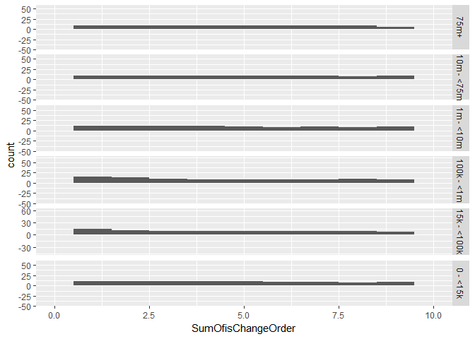

```r
ggplot(
  data = subset(NChgCeil,SumOfisChangeOrder>0),
  aes_string(x = "SumOfisChangeOrder")
  ) + geom_bar(binwidth=1) +
    facet_grid( Ceil ~ .,
                scales = "free_y",
                space = "free_y") + scale_y_continuous(expand = c(0,50)) +scale_x_continuous(limits=c(0,10))
```

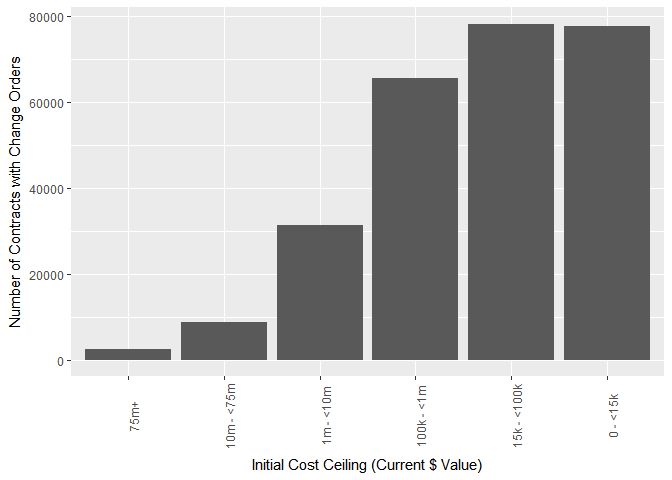

```r
ggplot(
  data = subset(NChgCeil,SumOfisChangeOrder>0),
  aes_string(x = "Ceil",weight="ContractCount"),
  main="Number of Contracts with Change Orders\nBy Initial Contract Ceiling")+
  geom_bar()+
    scale_x_discrete("Initial Cost Ceiling (Current $ Value)")+scale_y_continuous("Number of Contracts with Change Orders")+theme(axis.text.x=element_text(angle=90))
```

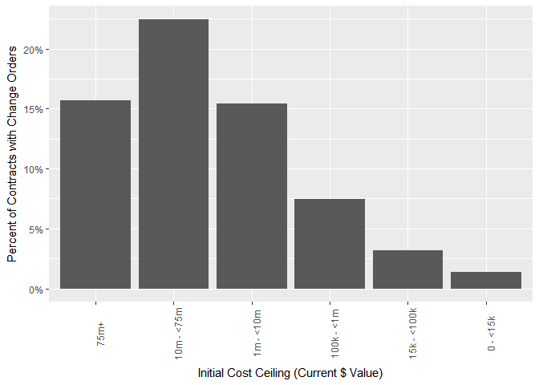

```r
ggplot(
  data = subset(NChgCeil,SumOfisChangeOrder>0),
  aes_string(x = "Ceil",weight="pContractByCeil"),
  main="Percentage of Contracts going to Contracts with Change Orders\nBy Initial Contract Ceiling")+ geom_bar()+ scale_y_continuous("Percent of Contracts with Change Orders", labels=percent)+
    scale_x_discrete("Initial Cost Ceiling (Current $ Value)")+theme(axis.text.x=element_text(angle=90))
```

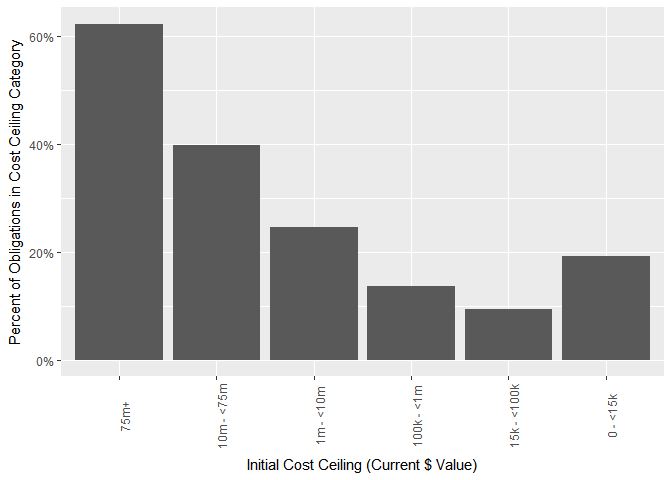

```r
ggplot(
  data =subset(NChgCeil,SumOfisChangeOrder>0),
  aes_string(x = "Ceil",weight="pObligationByCeil"),
  main="Percentage of Contract Obligations going to Contracts with Change Orders\nBy Initial Contract Ceiling"
  )+ geom_bar()+ scale_y_continuous("Percent of Obligations in Cost Ceiling Category", labels=percent)+
    scale_x_discrete("Initial Cost Ceiling (Current $ Value)")+theme(axis.text.x=element_text(angle=90))
```

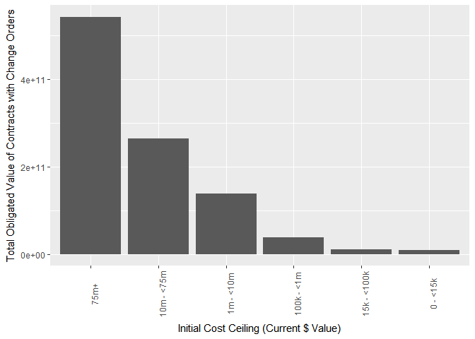

```r
ggplot(
  data = subset(NChgCeil,SumOfisChangeOrder>0),
  aes_string(x = "Ceil",weight="Action.Obligation")
  )+ geom_bar()+
    scale_x_discrete("Initial Cost Ceiling (Current $ Value)")+scale_y_continuous("Total Obligated Value of Contracts with Change Orders")+theme(axis.text.x=element_text(angle=90))
```

```r
sum(subset(NChgCeil,SumOfisChangeOrder>0)$pTotalObligation)
```

```
## [1] 0.3954099
```

```r
sum(subset(NChgCeil,SumOfisChangeOrder>0)$pTotalContract)
```

```
## [1] 0.02841951
```

## Costly Change Orders Potential Change Cost

### Size of change orders measured by raise of ceiling

This study uses changes in the *Base and All Options Value Amount* as a way of tracking the potential cost of change orders.

- The *Base and All Options Value Amount* refers to the ceiling of contract costs if all available options were exercised.
- The *Base and Exercised Value Amount* is not used because contracts are often specified such that the bulk of the eventually executed contract in dollar terms are treated as options. In these cases, the all-inclusive value provides a better baseline for tracking growth.
- The *Action Obligation* refers to the actual amount transferred to vendors. This study team does not use this value because spending for change orders are not necessarily front-loaded. For example, a change to a contract in May of 2010 could easily result in payments from May 2010 through August 2013.

The % Growth in Base and All Options Value Amount form Change Orders is calculated as follows:

*Base and All Options Value Amount* increases for all Change Order Modifications/ *Base and All Options Value Amount* from the original unmodified contract transaction

**A histogram of the data** showing the distribution of the initial amount of the specific change order

```r
pChgCeil<-ddply(CompleteModelAndDetail,
             .(pChange3Sig,
               StartFiscalYear,
               Ceil),
             plyr::summarise,
             ContractCount=length(CSIScontractID),
             Action.Obligation=sum(Action.Obligation))

pChgCeil<-ddply(pChgCeil,
                .(Ceil),
                transform,
                pContractByCeil=ContractCount/sum(ContractCount),
                pObligationByCeil=Action.Obligation/sum(Action.Obligation))

pChgCeil<-ddply(pChgCeil,
                .(StartFiscalYear),
                transform,
                pContractByFYear=ContractCount/sum(ContractCount),
                pObligationByFYear=Action.Obligation/sum(Action.Obligation))

pChgCeil$pChange3Sig[pChgCeil$pChange3Sig==-Inf]<-NA
pChgCeil$pChange3Sig[pChgCeil$pChange3Sig==Inf]<-NA

pChgCeilAverage<-ddply(pChgCeil,
                .(Ceil),
                plyr::summarise,
                mean = wtd.mean(pChange3Sig,ContractCount),
                sd   = sqrt(wtd.var(pChange3Sig,ContractCount))
                # se   = sd / sqrt(ContractCount)
                )




pChgCeil$pTotalObligation<-pChgCeil$Action.Obligation/sum(NChgCeil$Action.Obligation,na.rm=TRUE)
pChgCeil$pTotalContract<-pChgCeil$ContractCount/sum(NChgCeil$ContractCount,na.rm=TRUE)

pChgCeil$CRai <- cut2(
    pChgCeil$pChange3Sig,c(
                                              -0.001,
                                              0.001,
                                              0.15)
    )
```

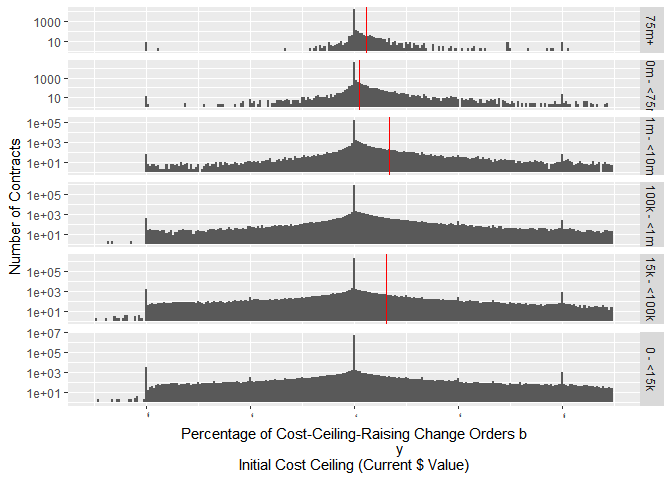

```r
ggplot(
  data = pChgCeil,
  aes_string(x = "pChange3Sig",
             weights = "ContractCount")
  ) + geom_histogram(binwidth=0.01) +
    facet_grid( Ceil ~ .,
                scales = "free_y",
                space = "free_y") +
    scale_y_log10("Number of Contracts")+
    scale_x_continuous("Percentage of Cost-Ceiling-Raising Change Orders b
                       y\nInitial Cost Ceiling (Current $ Value)",
                       limits=c(-1.25,1.25), labels=percent)+
    theme(axis.text.x=element_text(angle=90,size=1))+
  geom_vline(data=pChgCeilAverage,aes(xintercept=mean),color="red")
```

[output not shown]

[output cut: 70 more lines]

[output not shown]

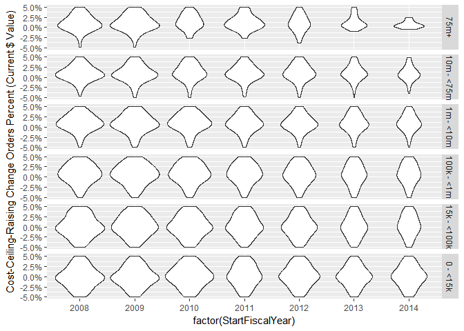

```r
# ggplot(
#   data = subset(pChgCeil,is.numeric(pChange3Sig)&is.finite(pChange3Sig)),
#   aes_string(y = "pChange3Sig")
#   ) + geom_boxplot()

ggplot(
  data = subset(pChgCeil,is.finite(pChange3Sig)&
                  !is.na(pChange3Sig)&StartFiscalYear>2007&StartFiscalYear<=2014&pChange3Sig!=0),
  aes(y = pChange3Sig,x=factor(StartFiscalYear),
             weight = ContractCount)
  ) + geom_violin() +
    facet_grid( Ceil ~ .) +
    # scale_y_log10("Number of Contracts",limits=c(-1.25,1.25))+
     scale_y_continuous(
       "Cost-Ceiling-Raising Change Orders Percent (Current $ Value)",
                       limits=c(-0.05,0.05), labels=percent)
```

[figure not shown]

```r
    # theme(axis.text.x=element_text(angle=90,size=1))



ggplot(
  data = subset(pChgCeil,is.finite(pChange3Sig)&
                  !is.na(pChange3Sig)&StartFiscalYear>2007&StartFiscalYear<=2014),
  aes(y = pChange3Sig,x=factor(StartFiscalYear),
             weight = ContractCount)
  ) + geom_boxplot(outlier.shape = NA,notch=TRUE) +
    facet_grid( Ceil ~ .) +
    # scale_y_log10("Number of Contracts",limits=c(-1.25,1.25))+
     scale_y_continuous(
       "Cost-Ceiling-Raising Change Orders Percent (Current $ Value)",
                       limits=c(-0.05,0.05), labels=percent)
```

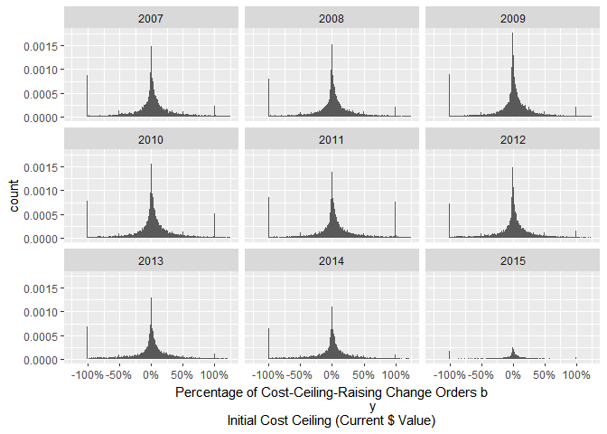

```r
    # theme(axis.text.x=element_text(angle=90,size=1))


# Percent of Contracts breakdown by StartYear
ggplot(
  data = subset(pChgCeil,
                StartFiscalYear>=2007 &
                  StartFiscalYear<=2015 &
                  pChange3Sig!=0),
  aes_string(x = "pChange3Sig",
             weight="pContractByFYear")
  ) + geom_histogram(binwidth=0.01) +
  scale_x_continuous("Percentage of Cost-Ceiling-Raising Change Orders b
                       y\nInitial Cost Ceiling (Current $ Value)",
                       limits=c(-1.25,1.25), labels=percent)+
  scale_y_continuous()+
  facet_wrap("StartFiscalYear")
```

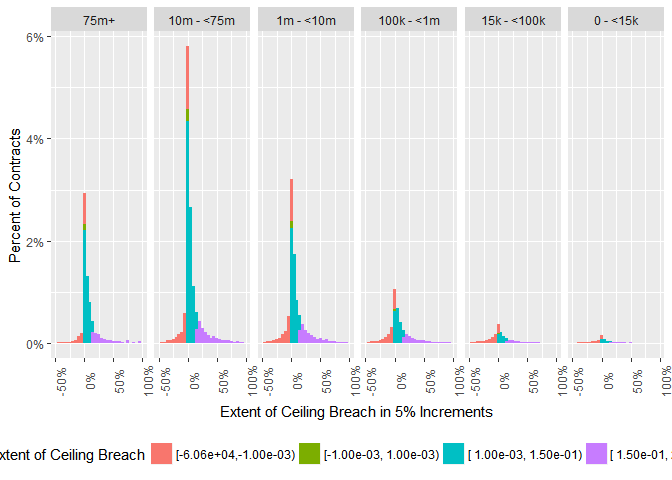

```r
# Percent of Contracts breakdown by Ceiling
ggplot(
  data = subset(pChgCeil,pChange3Sig!=0),
  aes_string(x = "pChange3Sig",weight="pContractByCeil",fill="CRai")#
  )+ geom_histogram(binwidth=0.05)+
#     scale_x_continuous("Percentage of Cost-Ceiling-Raising Change Orders by\nInitial Cost Ceiling (Current $ Value)")
    scale_y_continuous("Percent of Contracts", labels=percent)+
        facet_grid( . ~ Ceil )+scale_x_continuous("Extent of Ceiling Breach in 5% Increments",limits=c(-0.5,1), labels=percent)+theme(axis.text.x=element_text(angle=90),legend.position="bottom")+scale_fill_discrete(name="Extent of Ceiling Breach")
```

```r
tapply(pChgCeil$pChange3Sig, pChgCeil$Ceil, summary)
```

```
## $`75m+`
##    Min. 1st Qu.  Median    Mean 3rd Qu.    Max.
##  -3.313   0.003   0.048   1.135   0.154 790.700
##
## $`10m - <75m`
##    Min. 1st Qu.  Median    Mean 3rd Qu.    Max.
## -8.2840 -0.0070  0.0730  0.3392  0.2480 61.1900
##
## $`1m - <10m`
##      Min.   1st Qu.    Median      Mean   3rd Qu.      Max.
##   -75.600    -0.052     0.142     5.106     0.474 28500.000
##
## $`100k - <1m`
##      Min.   1st Qu.    Median      Mean   3rd Qu.      Max.
##    -109.2      -0.1       0.2     189.4       0.7 2316000.0
##
## $`15k - <100k`
##     Min.  1st Qu.   Median     Mean  3rd Qu.     Max.
##  -1291.0     -0.3      0.2     23.2      0.8 354500.0
##
## $`0 - <15k`
##     Min.  1st Qu.   Median     Mean  3rd Qu.     Max.     NA's
##   -60650        0        0     2497        1 20440000       26
```

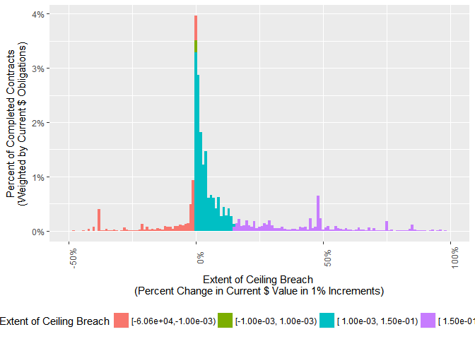

```r
#Percent of obligations breakdown
ggplot(
  data = subset(pChgCeil,pChange3Sig!=0),
  aes_string(x = "pChange3Sig",weight="pTotalObligation",fill="CRai")#
  )+ geom_bar(binwidth=0.01)+
#     scale_x_continuous("Percentage of Obligations  by\nInitial Cost Ceiling (Current $ Value)")
    scale_y_continuous("Percent of Completed Contracts\n(Weighted by Current $ Obligations)", labels=percent)+
       # facet_grid( . ~ Term )+
    scale_x_continuous("Extent of Ceiling Breach \n(Percent Change in Current $ Value in 1% Increments)",labels=percent,limits=c(-0.5,1))+
    coord_cartesian(xlim=c(-0.5,1))+ theme(axis.text.x=element_text(angle=90),legend.position="bottom")+
    scale_fill_discrete(name="Extent of Ceiling Breach")
```

```r
tapply(pChgCeil$CRai, pChgCeil$Ceil, summary)
```

```
## $`75m+`
## [-6.06e+04,-1.00e-03) [-1.00e-03, 1.00e-03) [ 1.00e-03, 1.50e-01)
##                   170                    21                   437
## [ 1.50e-01, 2.04e+07]
##                   217
##
## $`10m - <75m`
## [-6.06e+04,-1.00e-03) [-1.00e-03, 1.00e-03) [ 1.00e-03, 1.50e-01)
##                   680                    26                   935
## [ 1.50e-01, 2.04e+07]
##                   900
##
## $`1m - <10m`
## [-6.06e+04,-1.00e-03) [-1.00e-03, 1.00e-03) [ 1.00e-03, 1.50e-01)
##                  2098                    30                  1270
## [ 1.50e-01, 2.04e+07]
##                  3280
##
## $`100k - <1m`
## [-6.06e+04,-1.00e-03) [-1.00e-03, 1.00e-03) [ 1.00e-03, 1.50e-01)
##                  4328                    34                  1334
## [ 1.50e-01, 2.04e+07]
##                  6646
##
## $`15k - <100k`
## [-6.06e+04,-1.00e-03) [-1.00e-03, 1.00e-03) [ 1.00e-03, 1.50e-01)
##                  6618                    30                  1337
## [ 1.50e-01, 2.04e+07]
##                  8388
##
## $`0 - <15k`
## [-6.06e+04,-1.00e-03) [-1.00e-03, 1.00e-03) [ 1.00e-03, 1.50e-01)
##                  6728                    35                  1340
## [ 1.50e-01, 2.04e+07]                  NA's
##                 10673                    26
```

```r
sum(subset(pChgCeil,pChange3Sig>0)$pTotalObligation)
```

```
## [1] 0.2615659
```

```r
# BreachSummary<-ddply(CompleteModelAndDetail,
#                      .(Ceil,
#                        pChange3Sig,
#                        SumOfisChangeOrder,
#                        CRai,
#                        Term),
#                      summarise,
#                      pContractByCeil=sum(pContractByCeil),
#                      pObligationByCeil=sum(pObligationByCeil),
#                      pTotalObligation=sum(pTotalObligation))
#
#
#
# ddply(pChgCeil,.(Term,CRai),
#                      summarise,
#                      pTotalObligation=sum(pTotalObligation))
```

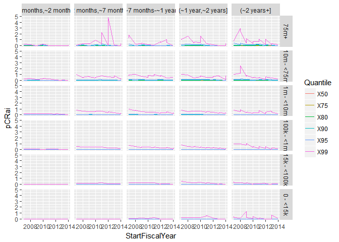

```r
df.QCrai<-ddply(subset(CompleteModelAndDetail,
                                        !is.na(Dur) &
               !is.na(Ceil) &
               !is.na(CRai) &
               StartFiscalYear>=2007 &
               StartFiscalYear<=2014 &
               (LastCurrentCompletionDate<=as.Date("2015-09-30") |
                    IsClosed==1) &
               UnmodifiedCurrentCompletionDate<as.Date("2015-09-30")),
      .(StartFiscalYear,
               Ceil,
               Dur),
      summarise,
      X50 = quantile(pChangeOrderUnmodifiedBaseAndAll, probs = 0.5,na.rm=TRUE),
      X75 = quantile(pChangeOrderUnmodifiedBaseAndAll, probs = 0.75,na.rm=TRUE),
      X80 = quantile(pChangeOrderUnmodifiedBaseAndAll, probs = 0.80,na.rm=TRUE),
      X90 = quantile(pChangeOrderUnmodifiedBaseAndAll, probs = 0.90,na.rm=TRUE),
      X95 = quantile(pChangeOrderUnmodifiedBaseAndAll, probs = 0.95,na.rm=TRUE),
      X99 = quantile(pChangeOrderUnmodifiedBaseAndAll, probs = 0.99,na.rm=TRUE),
      ContractCount=length(CSIScontractID),
             Action.Obligation=sum(Action.Obligation),
      metric="Contracts within Period")



df.QCrai<-rbind(df.QCrai,
                ddply(subset(CompleteModelAndDetail,
                                               !is.na(Dur) &
                                               !is.na(Ceil) &
                                               !is.na(CRai) &
                                               StartFiscalYear>=2007 &
                                               StartFiscalYear<=2014),
      .(StartFiscalYear,
               Ceil,
               Dur),
      summarise,
      X50 = quantile(pChangeOrderUnmodifiedBaseAndAll, probs = 0.5,na.rm=TRUE),
      X75 = quantile(pChangeOrderUnmodifiedBaseAndAll, probs = 0.75,na.rm=TRUE),
      X80 = quantile(pChangeOrderUnmodifiedBaseAndAll, probs = 0.80,na.rm=TRUE),
      X90 = quantile(pChangeOrderUnmodifiedBaseAndAll, probs = 0.90,na.rm=TRUE),
      X95 = quantile(pChangeOrderUnmodifiedBaseAndAll, probs = 0.95,na.rm=TRUE),
      X99 = quantile(pChangeOrderUnmodifiedBaseAndAll, probs = 0.99,na.rm=TRUE),
      ContractCount=length(CSIScontractID),
             Action.Obligation=sum(Action.Obligation),
      metric="Early Results for All Contracts")
)

df.QCrai<-melt(df.QCrai,variable.name="Quantile",value.name="pCRai",measure.vars=c(
  "X50",
  "X75",
  "X80",
  "X90",
  "X95",
  "X99")
)

ggplot(df.QCrai,
       aes(x=StartFiscalYear,y=pCRai,color=Quantile))+
  geom_line()+
  facet_grid(Ceil~Dur)
```

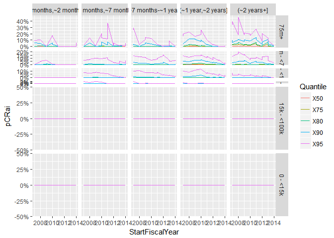

```r
ggplot(subset(df.QCrai,
                !Quantile %in% c("X99")),
       aes(x=StartFiscalYear,y=pCRai,color=Quantile))+
  geom_line()+
  facet_grid(Ceil~Dur,
             scales="free_y",
             space="free_y")+
  scale_y_continuous(labels=percent)
```

```r
#Test to see which percentiles register at all.
df.ecdf<-ddply(CompleteModelAndDetail,
      .(Ceil,
               Dur),
      summarise,
      r001 = ecdf(pChangeOrderUnmodifiedBaseAndAll)(0.001),
      r01 = ecdf(pChangeOrderUnmodifiedBaseAndAll)(0.01),
      r05 = ecdf(pChangeOrderUnmodifiedBaseAndAll)(0.01)
)

# df.ecdf<-subset(df.ecdf,StartFiscalYear>=2007&StartFiscalYear<=2014)

# test<-tapply(CompleteModelAndDetail, pChangeOrderUnmodifiedBaseAndAll, ecdf)
```

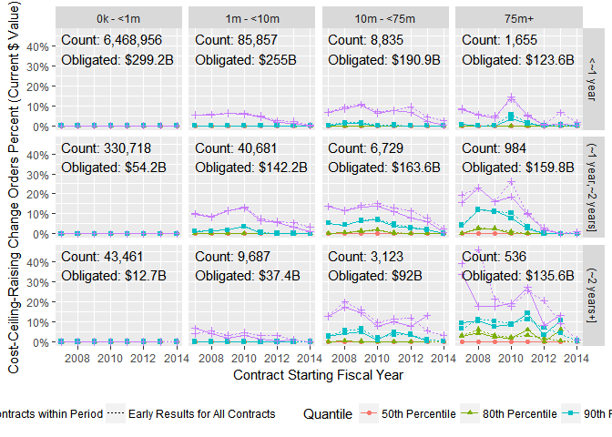

```r
df.QCrai.SDur<-ddply(subset(CompleteModelAndDetail,
                                        !is.na(Dur.Simple) &
               !is.na(Ceil.Big) &
               !is.na(CRai) &
               StartFiscalYear>=2007 &
               StartFiscalYear<=2014 &
               (LastCurrentCompletionDate<=as.Date("2015-09-30") |
                    IsClosed==1) &
               UnmodifiedCurrentCompletionDate<as.Date("2015-09-30")),
      .(StartFiscalYear,
               Ceil.Big,
               Dur.Simple),
      summarise,
      X50 = quantile(pChangeOrderUnmodifiedBaseAndAll, probs = 0.5,na.rm=TRUE),
      X75 = quantile(pChangeOrderUnmodifiedBaseAndAll, probs = 0.75,na.rm=TRUE),
      X80 = quantile(pChangeOrderUnmodifiedBaseAndAll, probs = 0.80,na.rm=TRUE),
      X90 = quantile(pChangeOrderUnmodifiedBaseAndAll, probs = 0.90,na.rm=TRUE),
      X95 = quantile(pChangeOrderUnmodifiedBaseAndAll, probs = 0.95,na.rm=TRUE),
      X99 = quantile(pChangeOrderUnmodifiedBaseAndAll, probs = 0.99,na.rm=TRUE),
      ContractCount=length(CSIScontractID),
             Action.Obligation=sum(Action.Obligation),
      metric="Contracts within Period")



df.QCrai.SDur<-rbind(df.QCrai.SDur,
                ddply(subset(CompleteModelAndDetail,
                                               !is.na(Dur.Simple) &
                                               !is.na(Ceil.Big) &
                                               !is.na(CRai) &
                                               StartFiscalYear>=2007 &
                                               StartFiscalYear<=2014),
      .(StartFiscalYear,
               Ceil.Big,
               Dur.Simple),
      summarise,
      X50 = quantile(pChangeOrderUnmodifiedBaseAndAll, probs = 0.5,na.rm=TRUE),
      X75 = quantile(pChangeOrderUnmodifiedBaseAndAll, probs = 0.75,na.rm=TRUE),
      X80 = quantile(pChangeOrderUnmodifiedBaseAndAll, probs = 0.80,na.rm=TRUE),
      X90 = quantile(pChangeOrderUnmodifiedBaseAndAll, probs = 0.90,na.rm=TRUE),
      X95 = quantile(pChangeOrderUnmodifiedBaseAndAll, probs = 0.95,na.rm=TRUE),
      X99 = quantile(pChangeOrderUnmodifiedBaseAndAll, probs = 0.99,na.rm=TRUE),
      ContractCount=length(CSIScontractID),
             Action.Obligation=sum(Action.Obligation),
      metric="Early Results for All Contracts")
)


df.QCrai.SDur<-melt(df.QCrai.SDur,
                      variable.name="Quantile",value.name="pCRai",measure.vars=c(
  "X50",
  "X75",
  "X80",
  "X90",
  "X95",
  "X99")
)

df.QCrai.SDur$Quantile<-factor(df.QCrai.SDur$Quantile,
  levels=c("X50",
  "X75",
  "X80",
  "X90",
  "X95",
  "X99"),
  labels=c("50th Percentile",
  "75th Percentile",
  "80th Percentile",
  "90th Percentile",
  "95th Percentile",
  "99th Percentile")
)

CRaiSDurCeilLabels<-ddply(
  subset(df.QCrai.SDur,Quantile=="50th Percentile" &
           metric=="Contracts within Period"),
    .(Dur.Simple,Ceil.Big),
    plyr::summarise,
    FacetCount=paste("Count:",prettyNum(sum(ContractCount),big.mark=",")),
    FacetValue=paste(FacetCount,"\nObligated: $",round(sum(Action.Obligation)/1000000000,1),"B",sep="")
    )

Ypos<-max(subset(df.QCrai.SDur,
                   !Quantile %in% c("99th Percentile")
                 )$pCRai,na.rm=TRUE)


CRaiOutput<-ggplot(subset(df.QCrai.SDur,
                !Quantile %in% c("99th Percentile",
                                 "75th Percentile")),
       aes(x=StartFiscalYear,y=pCRai,color=Quantile))+
  geom_line(aes(linetype=metric))+
  geom_point(aes(shape=Quantile))+
  geom_text(data=CRaiSDurCeilLabels,
              aes(x=2007,y=Ypos,label=FacetValue),
              # parse=TRUE,
              hjust=0,
              vjust=1,
              color="black")+
  facet_grid(Dur.Simple~Ceil.Big)+
               scale_y_continuous("Cost-Ceiling-Raising Change Orders Percent (Current $ Value)",
                                  labels=percent)+
  scale_x_continuous("Contract Starting Fiscal Year")+
  scale_linetype_discrete("Early Results")+
  theme(legend.position="bottom") #, position=pd

CRaiOutput
```

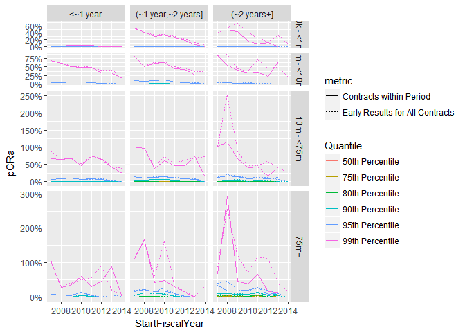

```r
ggsave("CRaiOutput.png",
       CRaiOutput,
       width=8,
       height=7,
       dpi=600)

ggplot(subset(df.QCrai.SDur,
                # !Quantile %in% c("99th Percentile")
                !Ceil.Big %in% c("15k - <100k","0 - <15k")
              ),
       aes(x=StartFiscalYear,
           y=pCRai,
           color=Quantile))+
  geom_line(aes(linetype=metric))+
  facet_grid(Ceil.Big~Dur.Simple,
             scales="free_y",
             space="free_y")+
  scale_y_continuous(labels=percent)
```

```r
#Test to see which percentiles register at all.
df.ecdf<-ddply(CompleteModelAndDetail,
      .(Ceil.Big,
               Dur.Simple),
      summarise,
      r001 = ecdf(pChangeOrderUnmodifiedBaseAndAll)(0.001),
      r01 = ecdf(pChangeOrderUnmodifiedBaseAndAll)(0.01),
      r05 = ecdf(pChangeOrderUnmodifiedBaseAndAll)(0.01)
)

# df.ecdf<-subset(df.ecdf,StartFiscalYear>=2007&StartFiscalYear<=2014)


CRaiSDurCeilFYearSummary<-ddply(
  subset(df.QCrai.SDur,Quantile=="50th Percentile" &
           metric=="Contracts within Period"),
    .(Dur.Simple,Ceil.Big,StartFiscalYear),
    plyr::summarise,
    FacetCount=paste("Count:",prettyNum(sum(ContractCount),big.mark=",")),
    FacetValue=paste(FacetCount,"\nObligated: $",round(sum(Action.Obligation)/1000000000,1),"B",sep="")
    )

DurBoundary<-subset(CompleteModelAndDetail,Ceil=="75m+"&
         Dur=="(~2 years+]"&
         StartFiscalYear==2013&
         UnmodifiedCurrentCompletionDate<as.Date("2015-09-30")
         )
```

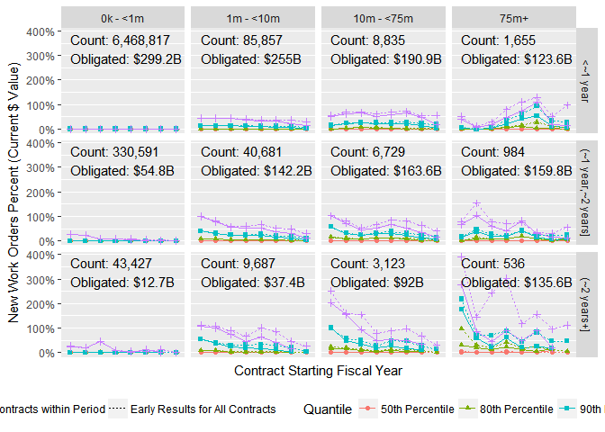

```r
df.QNWork.SDur<-ddply(subset(CompleteModelAndDetail,
                                        !is.na(Dur.Simple) &
               !is.na(Ceil.Big) &
               !is.na(pNewWorkUnmodifiedBaseAndAll) &
               StartFiscalYear>=2007 &
               StartFiscalYear<=2014 &
               (LastCurrentCompletionDate<=as.Date("2015-09-30") |
                    IsClosed==1) &
               UnmodifiedCurrentCompletionDate<as.Date("2015-09-30")),
      .(StartFiscalYear,
               Ceil.Big,
               Dur.Simple),
      summarise,
      X50 = quantile(pNewWorkUnmodifiedBaseAndAll, probs = 0.5,na.rm=TRUE),
      X75 = quantile(pNewWorkUnmodifiedBaseAndAll, probs = 0.75,na.rm=TRUE),
      X80 = quantile(pNewWorkUnmodifiedBaseAndAll, probs = 0.80,na.rm=TRUE),
      X90 = quantile(pNewWorkUnmodifiedBaseAndAll, probs = 0.90,na.rm=TRUE),
      X95 = quantile(pNewWorkUnmodifiedBaseAndAll, probs = 0.95,na.rm=TRUE),
      X99 = quantile(pNewWorkUnmodifiedBaseAndAll, probs = 0.99,na.rm=TRUE),
      ContractCount=length(CSIScontractID),
             Action.Obligation=sum(Action.Obligation),
      metric="Contracts within Period")



df.QNWork.SDur<-rbind(df.QNWork.SDur,
                ddply(subset(CompleteModelAndDetail,
                                               !is.na(Dur.Simple) &
                                               !is.na(Ceil.Big) &
                                               !is.na(pNewWorkUnmodifiedBaseAndAll) &
                                               StartFiscalYear>=2007 &
                                               StartFiscalYear<=2014),
      .(StartFiscalYear,
               Ceil.Big,
               Dur.Simple),
      summarise,
      X50 = quantile(pNewWorkUnmodifiedBaseAndAll, probs = 0.5,na.rm=TRUE),
      X75 = quantile(pNewWorkUnmodifiedBaseAndAll, probs = 0.75,na.rm=TRUE),
      X80 = quantile(pNewWorkUnmodifiedBaseAndAll, probs = 0.80,na.rm=TRUE),
      X90 = quantile(pNewWorkUnmodifiedBaseAndAll, probs = 0.90,na.rm=TRUE),
      X95 = quantile(pNewWorkUnmodifiedBaseAndAll, probs = 0.95,na.rm=TRUE),
      X99 = quantile(pNewWorkUnmodifiedBaseAndAll, probs = 0.99,na.rm=TRUE),
      ContractCount=length(CSIScontractID),
             Action.Obligation=sum(Action.Obligation),
      metric="Early Results for All Contracts")
)


df.QNWork.SDur<-melt(df.QNWork.SDur,
                      variable.name="Quantile",value.name="pNWork",measure.vars=c(
  "X50",
  "X75",
  "X80",
  "X90",
  "X95",
  "X99")
)

df.QNWork.SDur$Quantile<-factor(df.QNWork.SDur$Quantile,
  levels=c("X50",
  "X75",
  "X80",
  "X90",
  "X95",
  "X99"),
  labels=c("50th Percentile",
  "75th Percentile",
  "80th Percentile",
  "90th Percentile",
  "95th Percentile",
  "99th Percentile")
)

NWorkSDurCeilLabels<-ddply(
  subset(df.QNWork.SDur,Quantile=="50th Percentile" &
           metric=="Contracts within Period"),
    .(Dur.Simple,Ceil.Big),
    plyr::summarise,
    FacetCount=paste("Count:",prettyNum(sum(ContractCount),big.mark=",")),
    FacetValue=paste(FacetCount,"\nObligated: $",round(sum(Action.Obligation)/1000000000,1),"B",sep="")
    )

Ypos<-max(subset(df.QNWork.SDur,
                   !Quantile %in% c("99th Percentile")
                 )$pNWork,na.rm=TRUE)


NWorkOutput<-ggplot(subset(df.QNWork.SDur,
                !Quantile %in% c("99th Percentile",
                                 "75th Percentile")),
       aes(x=StartFiscalYear,y=pNWork,color=Quantile))+
  geom_line(aes(linetype=metric))+
  geom_point(aes(shape=Quantile))+
  geom_text(data=NWorkSDurCeilLabels,
              aes(x=2007,y=Ypos,label=FacetValue),
              # parse=TRUE,
              hjust=0,
              vjust=1,
              color="black")+
  facet_grid(Dur.Simple~Ceil.Big)+
               scale_y_continuous("New Work Orders Percent (Current $ Value)",
                                  labels=percent)+
  scale_x_discrete("Contract Starting Fiscal Year")+
  scale_linetype_discrete("Early Results")+
  theme(legend.position="bottom") #, position=pd

NWorkOutput
```

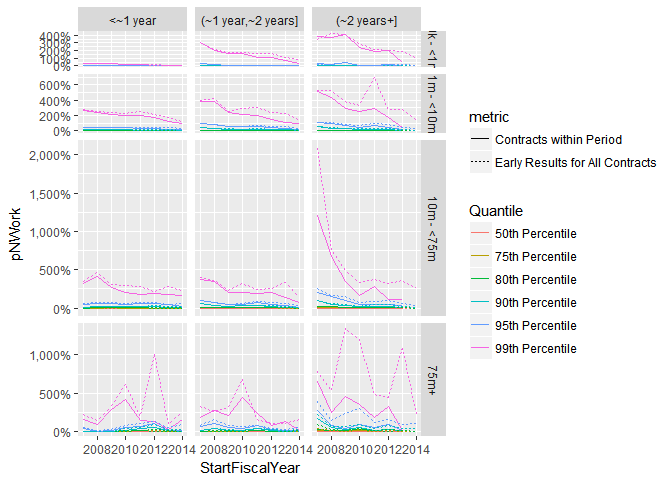

```r
ggplot(subset(df.QNWork.SDur,
                # !Quantile %in% c("99th Percentile")
                !Ceil.Big %in% c("15k - <100k","0 - <15k")
              ),
       aes(x=StartFiscalYear,
           y=pNWork,
           color=Quantile))+
  geom_line(aes(linetype=metric))+
  facet_grid(Ceil.Big~Dur.Simple,
             scales="free_y",
             space="free_y")+
  scale_y_continuous(labels=percent)
```

```r
#Test to see which percentiles register at all.
df.ecdf<-ddply(CompleteModelAndDetail,
      .(Ceil.Big,
               Dur.Simple),
      summarise,
      r001 = ecdf(pNewWorkUnmodifiedBaseAndAll)(0.001),
      r01 = ecdf(pNewWorkUnmodifiedBaseAndAll)(0.01),
      r05 = ecdf(pNewWorkUnmodifiedBaseAndAll)(0.01)
)

# df.ecdf<-subset(df.ecdf,StartFiscalYear>=2007&StartFiscalYear<=2014)


NWorkSDurCeilFYearSummary<-ddply(
  subset(df.QNWork.SDur,Quantile=="50th Percentile" &
           metric=="Contracts within Period"),
    .(Dur.Simple,Ceil.Big,StartFiscalYear),
    plyr::summarise,
    FacetCount=paste("Count:",prettyNum(sum(ContractCount),big.mark=",")),
    FacetValue=paste(FacetCount,"\nObligated: $",round(sum(Action.Obligation)/1000000000,1),"B",sep="")
    )

DurBoundary<-subset(CompleteModelAndDetail,Ceil=="75m+"&
         Dur=="(~2 years+]"&
         StartFiscalYear==2013&
         UnmodifiedCurrentCompletionDate<as.Date("2015-09-30")
         )
```